## Lecture 2: Risk and Return

## Measuring Assets’ Returns

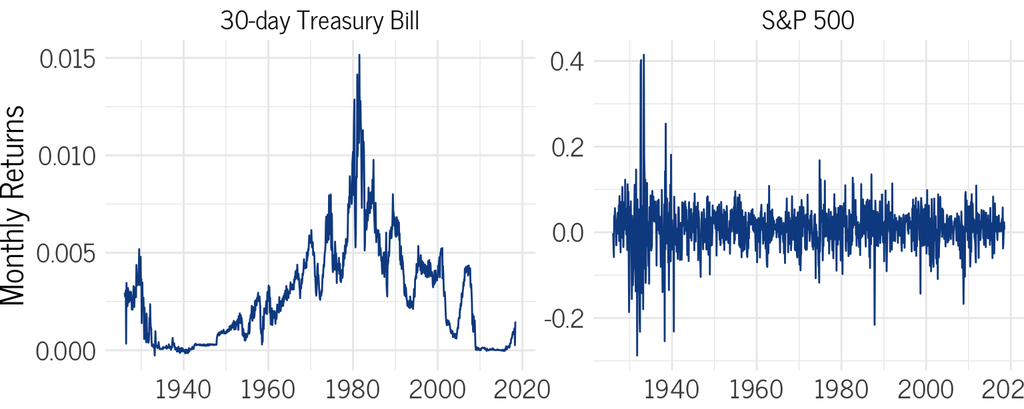

- Let’s begin by focusing on two major asset classes - stocks and bonds
- How have these assets performed historically?
  - What’s the best way to summarize their risk + return?

## Measuring Assets’ Returns

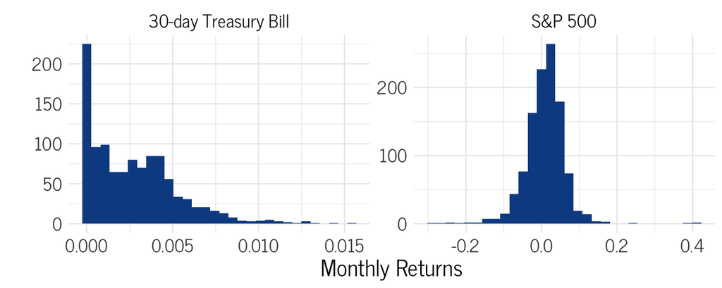

- Why does a Treasury bill’s return not fall below zero?
- Is monthly return the best measure? What else could we do?
  - Let’s quickly refresh ourselves on how to measure returns.

## Return Definitions

- The rate of return is also known as the **“net return”**
  $$r_{t} = \frac{P_{t} + D_{t}}{P_{t-1}} - 1$$
- **Gross returns** (sometimes $R_{t}$) is referred to as $1+r_{t}$
- The risk-free rate will be called $r_{f}$
  - How can I get the risk-free rate?
- **Excess returns** above the risk free rate are $r_{e} = r - r_{f}$

## Return Defintions

A holding-period return of $T$ years is

$$r_{0,T} = (1+r_{1})(1+r_{2})\ldots (1+r_{T}) - 1$$

- How you measure the holding period matters a ton!
- Recall the mutual fund experiment

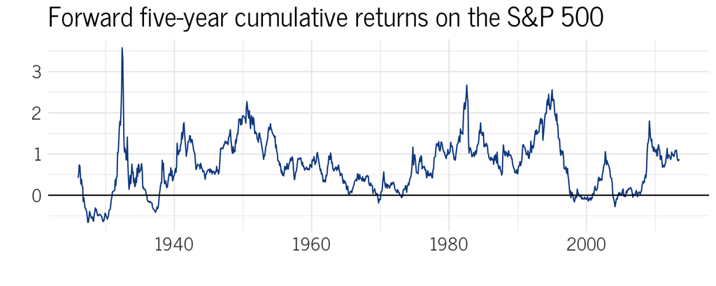

## Return Definitions

- How do we compare returns across different horizons?
  - Say I want to compare a window of cumulative returns 5 v 10 years.
- Annualized returns on the cumulative return:
  $$\widetilde{r}_{0,T} = (1+r_{0,T})^{\frac{1}{T_{\text{years}}}} - 1$$

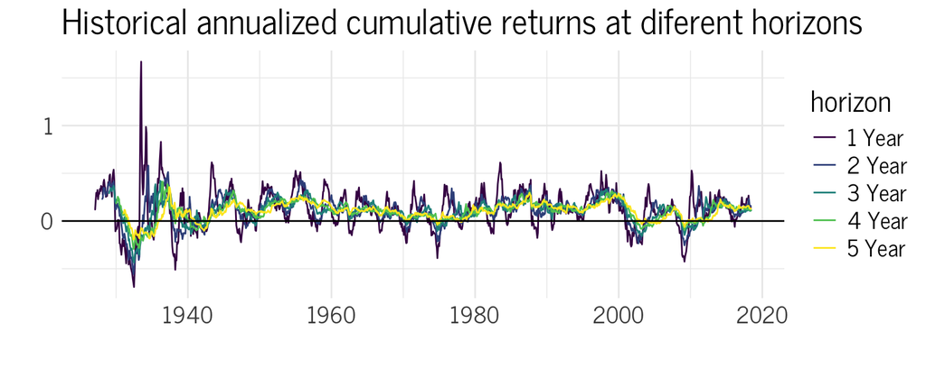

## Return Definitions

- Arithmetic average returns
  $$\overline{r} = \frac{1}{T}(r_{1} + r_{2} + \ldots + r_{T})$$
- Geometric average returns
  $$r_{G} = \left[(1+r_{1})(1+r_{2})\ldots (1+r_{T})\right]^{\frac{1}{T}} -
  1 = \big[\frac{P_{T}}{P_{0}}\big]^{\frac{1}{T}} - 1$$
  - Arithmetic average is unbiased estimate of 1-period future returns *(expected returns)*
  - Geometric average is a measure of cumulative past performance

## Return Definitions

- We calculate estimates of variance using squared deviations from arithmetic average returns
  $$\sigma^{2}(r) = VAR(r) = \frac{1}{T}\bigg((r_{1}-\overline{r})^{2} +
  (r_{2}-\overline{r})^{2} + \ldots + (r_{T}-\overline{r})^{2})\bigg)$$
- Standard deviation is the square-root of variance:
  $$\sigma(r) = SD(r) = \sqrt{\frac{1}{T}\bigg((r_{1}-\overline{r})^{2} +
  (r_{2}-\overline{r})^{2} + \ldots + (r_{T}-\overline{r})^{2})\bigg)}$$

## Return Defintions

- Finally, **covariance** measures how two returns move together
  $$\begin{aligned}
  \sigma_{i,j} = COV(r_{i}, r_{j}) =
  \frac{1}{T}\bigg((r_{1,i}-\overline{r}_{i})(r_{1,j}-\overline{r}_{j})
  &+ (r_{2,i}-\overline{r}_{i})(r_{2,j}-\overline{r}_{j})\\
  &+ \ldots +
  (r_{T,i}-\overline{r}_{i})(r_{T,j}-\overline{r}_{j})\bigg)
  \end{aligned}$$
- Correlations scale the covariance by standard deviations
  $$\rho_{i,j} = \frac{\sigma_{i,j}}{\sigma_{i}\sigma_{j}}$$
- Excel provides functions AVERAGE,GEOMEAN,VAR, STDEV, and COVAR

## Wanted: Information about risk and return

- To make investment decisions, we need to know
  - … the expected **future** returns
  - … the riskiness of **future** returns
- We turn to historical return data for these
  - A caveat…
  - The data give a pretty good sense of the risk, but expected returns are hard to measure.
  - Why?

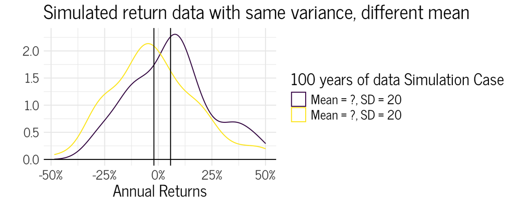

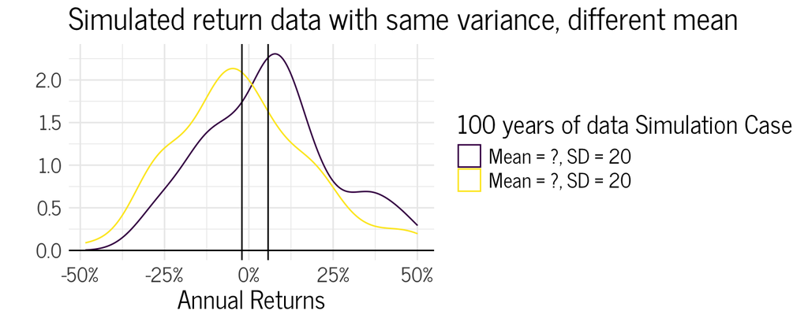

Mean 1 (purple): 5.72

Mean 2 (yellow): -2.05

True distributions:

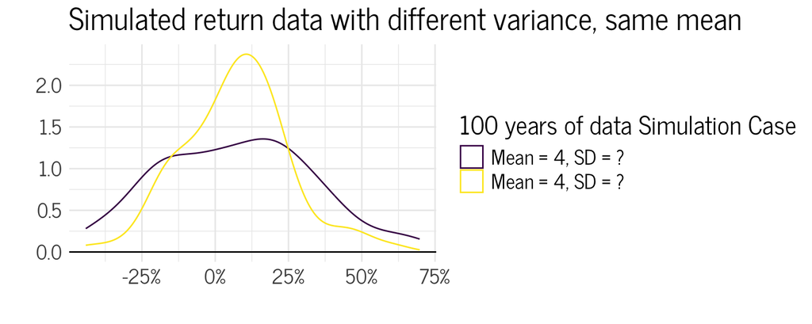

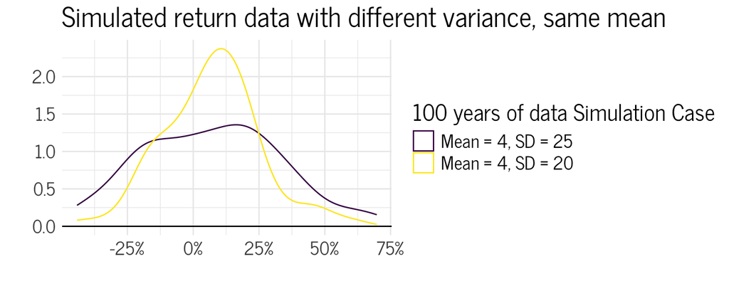

## Asset Returns: Historical Record

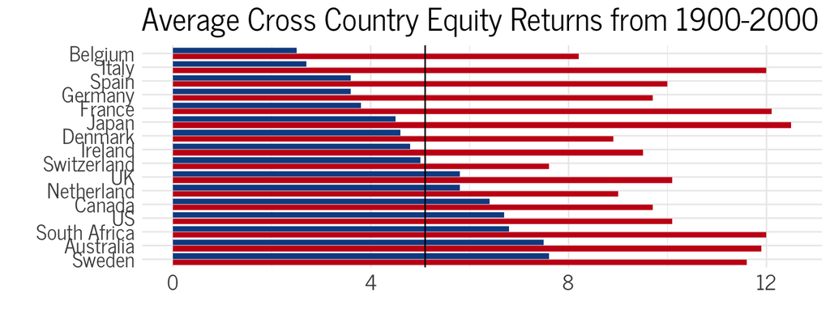

- US returns high, but not an outlier

## Asset Returns: Historical Record

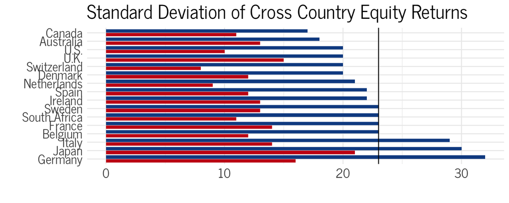

- Average s.d. of returns is 23% (US 20%)
- What’s up with Italy, Germany, Japan?

## High returns or survivorship bias? (Jorion and Goetzmann (1999))

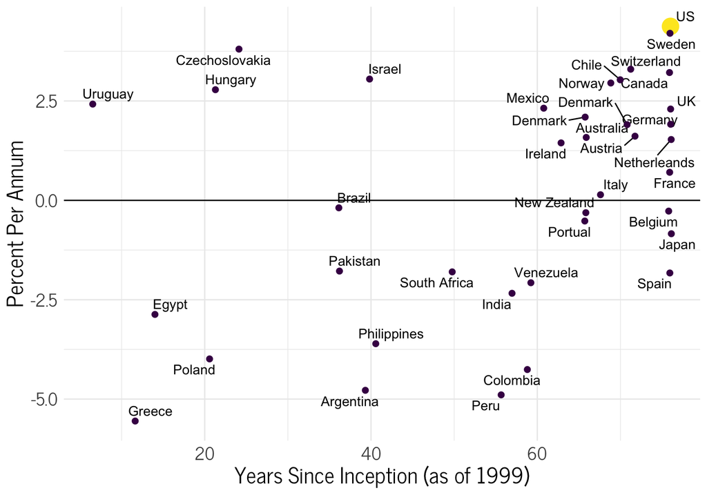

- Countries with low returns fall out of the analysis
- Median real return of all other countries is 0.75% (compared to 4.3% for US).

## High returns or survivorship bias? (Anarkulova et al. 2020)

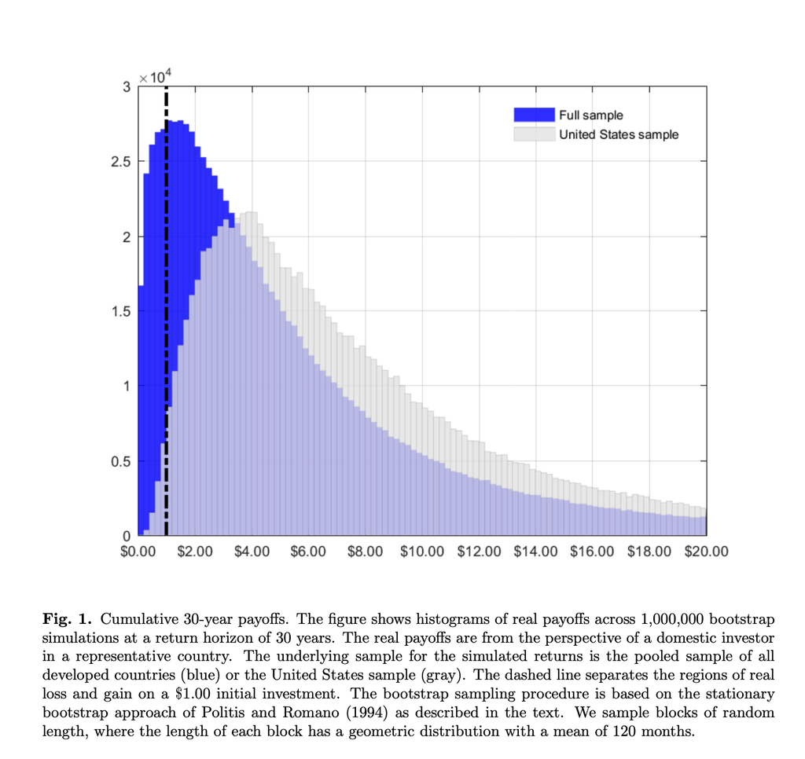

- “From 1990 to 2019, a diversified investment in Japanese stocks produced returns of -9% in nominal terms” Anarkulova et al. 2020
- Incorporating the losses from buy-and-hold strategies that were selected away.

## Still waiting for data?

Most recent U.S. historical data suggest:

- Average excess returns of large stocks over long term bonds ($r_{e}$) of roughly 6% … with a standard deviation of 20% ($\sigma_{e}$)
- With 81 years of data, **standard error** associated with mean excess returns is
  $$\sigma(\overline{r}_{e}) = \frac{\sigma(r_{e})}{\sqrt{T}} = \frac{20
  \%}{9} \approx 2.2\%$$
- Can we reject the null hypothesis that excess returns are 4%… or 2%?

## How can we forecast returns going forward?

Recall that

$$r_{1} = \underbrace{\frac{D_{1}}{P_{0}}}_{\text{dividend yield}} +
\underbrace{\frac{P_{1}}{P_{0}}}_{\text{growth}}$$

Also,

$$\underbrace{\frac{D_{1}}{P_{0}}}_{\text{dividend yield}} =
\text{earnings payout share} \times \frac{E_{1}}{P_{0}}$$
where, $E_{1}$ is earnings.

This implies
$$r_{1} = \text{firm's payout share} \times \frac{E_{1}}{P_{0}} +
\text{growth}$$

## The Gordon Model

$$r_{1} = \text{payout share} \times \frac{E_{1}}{P_{0}} + \text{growth}$$

- Historically, payout has been around 50%, P/E about 25 and growth rate of about 4-5% (nominal)
  - What does that imply about nominal expected returns?
- Estimate is about 6-7% nominal expected return for stocks, or 4% real, or a risk premium of 2-3% over nominal bonds
- This is low versus history
- To believe anything else, you must disagree with payout, E/P, or growth.

## Shiller Price-Earnings Ratios

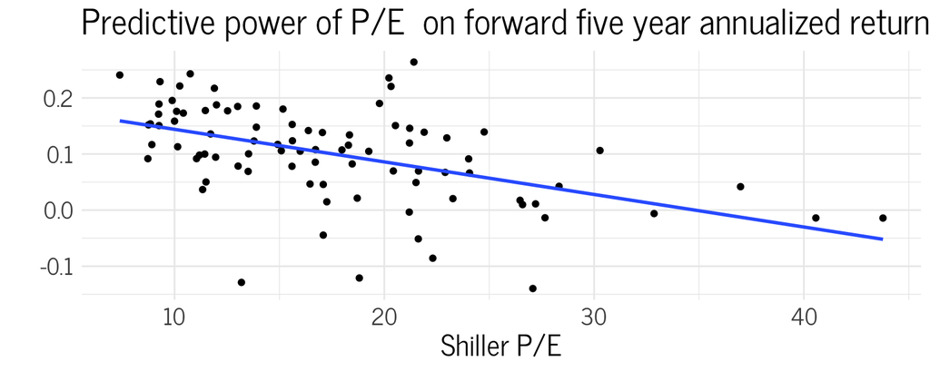

## Shiller Price-Earnings Ratios

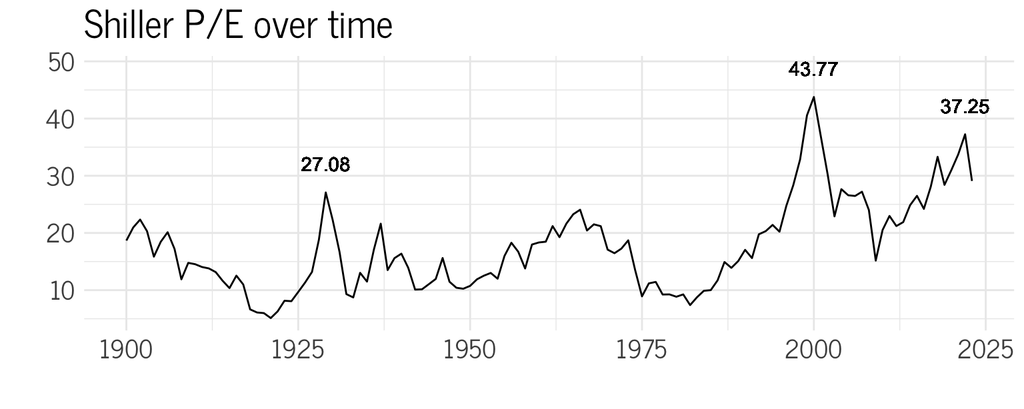

## Other risk measures

Value at Risk (VaR)

- A measure of loss most frequently associated with extreme negative returns
- VaR is the quantile of a distribution below which lies q % of the possible values of that distribution
- The 5% VaR, commonly estimated in practice, tells us how bad returns (or losses) will be in the worst 5% of times

## VaR under normality

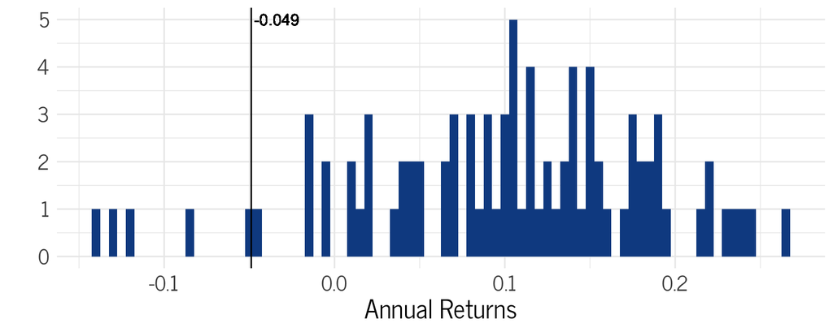

## Expected Shortfall (ES)

- Also called conditional tail expectation (CTE)
- More conservative measure of downside risk than VaR
  - VaR takes the highest return from the worst cases
  - ES takes an average return of the worst cases

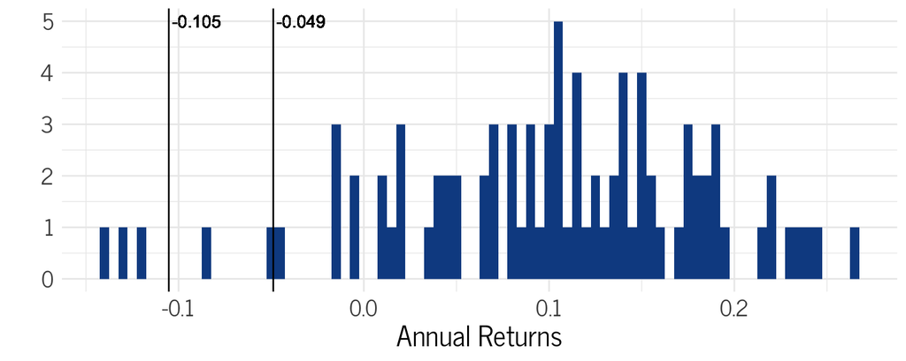

# Others?

- How would you want to model risk?

## Takeaways

- We still have a limited amount of high quality data to make inferences from, but…
- Historical data suggests a premium for risk in asset returns, but the size of the premium is up for debate
- If expected returns for the **aggregate stock market** with 80+ years of data are so imprecise, what are we to do with individual stocks?
- Need more than data to understand expected returns